# A5Q5.1

Joshua Levine

2026-02-02

## Question

Use the ‘Vocab’ data set in the ‘car’ package. It records a vocabulary score for over $30,000$ subjects tested over the years between 1974 and 2016.

Explore the following questions. Use appropriate tables and graphs to explain your findings.

1. Consider the distribution of education. Are there any salient features for this distribution?

## Answer

```r
# Import the required packages
library(car)
library(spida2)
library(ggplot2)
library(dplyr)
```

We will first consider the univariate distribution of the “education” variable.

```r
# Obtain a summary and quantile plot of the "education" variable
summary(Vocab$education)
```

```
##    Min. 1st Qu.  Median    Mean 3rd Qu.    Max.
##    0.00   12.00   12.00   13.03   15.00   20.00
```

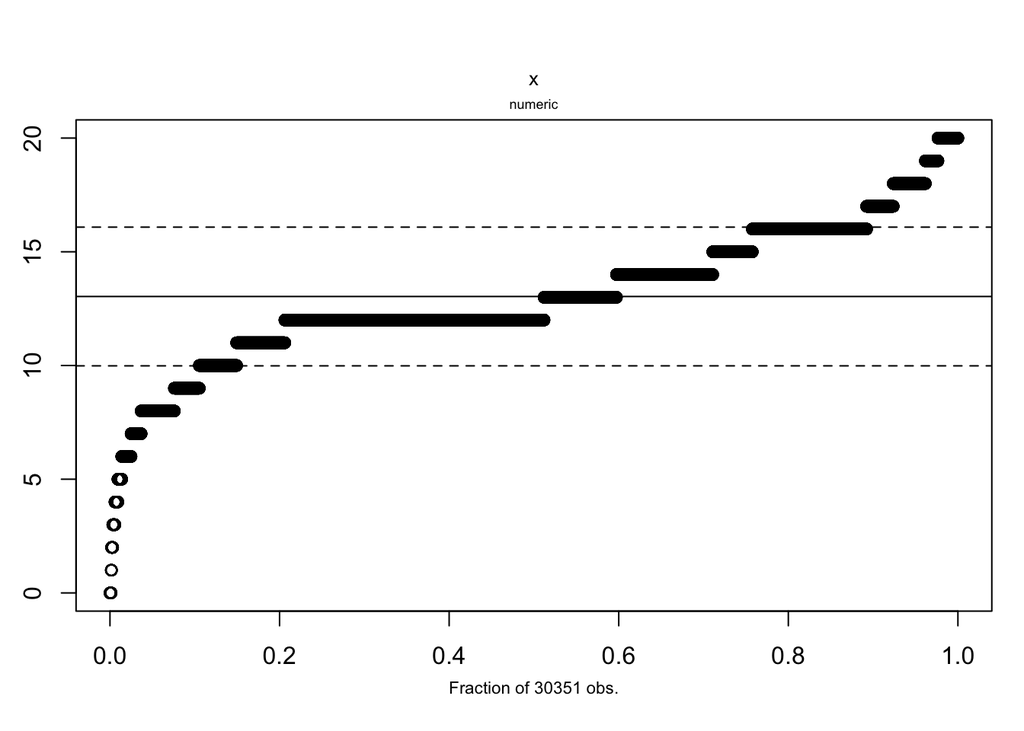

```r
xqplot(Vocab$education)
```

The univariate distribution of the “education” variable exhibits the following features:

- Heavy concentration around the mean. As indicated by the dashed lines in the above quantile plot, around $3/4$ of the data lies within one standard deviation of the mean. We compute the exact proportion in the below code and find that it is about $78.7\%$.
  - Consequently, the “education” variable is (at least somewhat) light-tailed.

```r
mean(abs(Vocab$education - mean(Vocab$education)) <= sd(Vocab$education))
```

```
## [1] 0.7869263
```

- A significant proportion of respondents had 12 years of education, clearly making it the mode.

As both the time period and one’s sex can plausibly influence one’s level of education, we will now investigate the relationship between the three variables. This will enable us to gain a more comprehensive view of the “education” variable and the dataset at large. As the dataset covers a long time period (1974 to 2016), we will split the years by decade (the dataset does not contain data for every individual year).

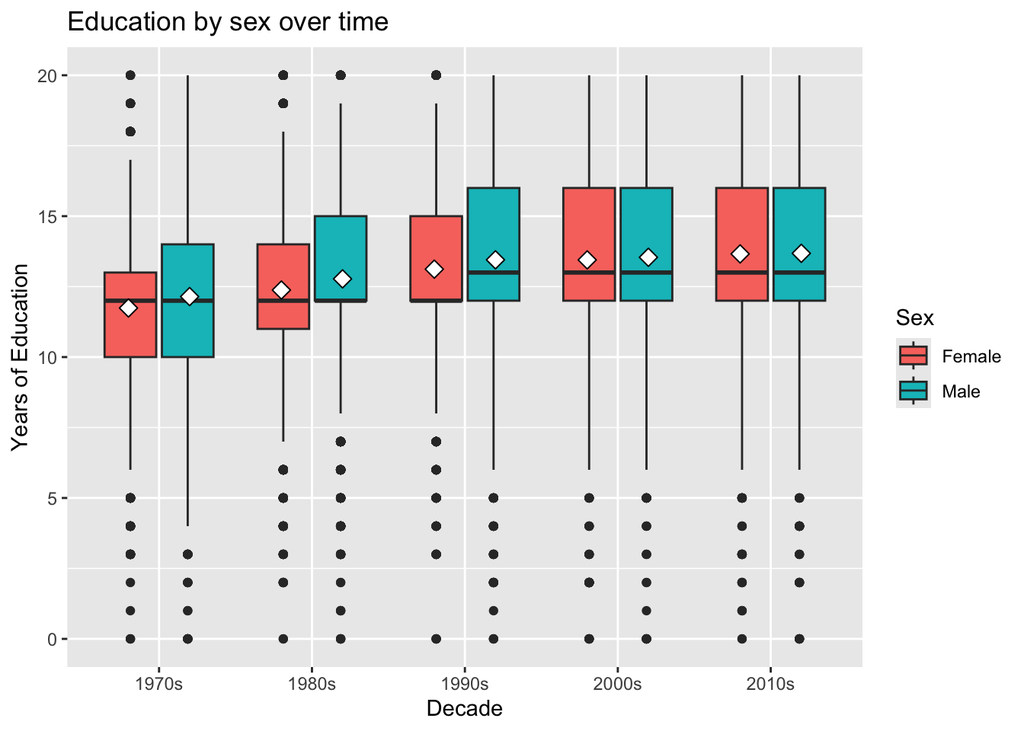

```r
Vocab %>%
  mutate(decade = factor(paste0(floor(year / 10) * 10, "s"))) %>%
  ggplot(aes(x = decade, y = education, fill = sex)) +
  geom_boxplot() +
  labs(
    title = "Education by sex over time",
    x = "Decade",
    y = "Years of Education",
    fill = "Sex"
  ) +
  stat_summary(
    aes(group = sex),
    fun = mean,
    geom = "point",
    shape = 23,
    size = 3,
    fill = "white",
    color = "black",
    position = position_dodge(width = 0.8)
  )
```

We can make the following observations: